# Problem Set 1: Randomization Inference - Answer Key

Author

MGMT 737 — Spring 2025

```r
library(tidyverse)
library(sandwich)
library(lmtest)

# Load the data
lalonde <- read_csv("../homework/data/lalonde_nsw.csv")

# Set seed for reproducibility
set.seed(42)
```

## Part A: Baseline Implementation (20 points)

### Question 1: Calculate the ATE using difference in means

```r
# ATE using difference in means
tau_ate <- mean(lalonde$re78[lalonde$treat == 1]) -
           mean(lalonde$re78[lalonde$treat == 0])

tau_ate
```

```
[1] 1794.342
```

The estimated ATE is **$1794.34**.

### Question 2: Calculate the ATT

```r
# ATT - average treatment effect on the treated
# Under randomization, we estimate this the same way
tau_att <- mean(lalonde$re78[lalonde$treat == 1]) -
           mean(lalonde$re78[lalonde$treat == 0])

tau_att
```

```
[1] 1794.342
```

The estimated ATT is **$1794.34**.

**Why are ATE and ATT numerically identical under complete randomization?**

Under complete randomization, treatment assignment is independent of potential outcomes. This means that the control group provides an unbiased estimate of the counterfactual outcomes for the treated group (what they would have earned without treatment). Since the control group is a random sample from the same population as the treated group, $E[Y_0 | W=1] = E[Y_0 | W=0]$. Therefore, the simple difference in means estimates both the ATE (average effect for everyone) and the ATT (average effect for the treated) without any bias.

### Question 3: Randomization Inference Test

```r
# Randomization inference for sharp null
n_perms <- 1000
n_treated <- sum(lalonde$treat)
n <- nrow(lalonde)

# Observed test statistic
obs_diff <- tau_ate

# Generate permutation distribution
perm_diffs <- numeric(n_perms)
for (i in 1:n_perms) {
  # Permute treatment labels (keeping fixed number treated)
  perm_treat <- sample(lalonde$treat)
  perm_diffs[i] <- mean(lalonde$re78[perm_treat == 1]) -
                   mean(lalonde$re78[perm_treat == 0])
}

# Two-sided p-value
p_ri <- mean(abs(perm_diffs) >= abs(obs_diff))

p_ri
```

```
[1] 0.002
```

The randomization inference p-value is **0.002**.

### Question 4: Comparison with Robust Standard Errors

```r
# Regression with HC2 robust standard errors
reg <- lm(re78 ~ treat, data = lalonde)
robust_test <- coeftest(reg, vcov = vcovHC(reg, type = "HC2"))

# Extract p-value for treatment coefficient
p_robust <- robust_test["treat", "Pr(>|t|)"]

p_robust
```

```
[1] 0.007769024
```

The p-value from regression with HC2 robust standard errors is **0.0078**.

**Comparison:** The two p-values are similar (RI: 0.002, Robust: 0.0078), which is expected in a reasonably sized sample. The randomization inference p-value is exact and valid in finite samples under the sharp null, while the robust regression p-value relies on asymptotic approximations.

## Part B: Extend the Estimator (35 points)

### Question 5: Stratified Randomization

```r
# Create strata based on married × nodegree
lalonde <- lalonde %>%
  mutate(strata = interaction(married, nodegree))

# Function to permute within strata
permute_within_strata <- function(data) {
  data %>%
    group_by(strata) %>%
    mutate(treat_perm = sample(treat)) %>%
    ungroup() %>%
    pull(treat_perm)
}

# Stratified randomization inference
perm_diffs_strat <- numeric(n_perms)
for (i in 1:n_perms) {
  perm_treat <- permute_within_strata(lalonde)
  perm_diffs_strat[i] <- mean(lalonde$re78[perm_treat == 1]) -
                         mean(lalonde$re78[perm_treat == 0])
}

# Two-sided p-value
p_ri_strat <- mean(abs(perm_diffs_strat) >= abs(obs_diff))

p_ri_strat
```

```
[1] 0.006
```

The stratified randomization inference p-value is **0.006**.

**Why does stratification matter?**

For the randomization inference, the distribution over $\Omega$, the sample space for treatments, can look very different (and less dispersed) under stratification, because mecahnically, stratification reduces the set of potential treatment assignments. Hence, if the variance of outcomes is at all correlated with the stratification groups, there will generally be wider variation in the randomization test without stratification.

For the estimate itself, ignoring stratification can be problematic if the likelihood of treatment is correlated with the efficacy of treatment. For example, if married individuals have more positive treatment effects and are more likely to be treated, then the estimate will misattribute the composition (more treated married indiviudals) with an actual treatment effect.

### Question 6: Covariate Adjustment

```r
# Regression-adjusted test statistic
get_adj_coef <- function(Y, W, data) {
  reg <- lm(Y ~ W + age + education + black + hispanic +
              married + nodegree + re74, data = data)
  coef(reg)["W"]
}

# Observed adjusted coefficient
obs_adj_coef <- coef(lm(re78 ~ treat + age + education + black + hispanic +
                         married + nodegree + re74, data = lalonde))["treat"]

# Covariate-adjusted randomization inference
perm_adj_coefs <- numeric(n_perms)
for (i in 1:n_perms) {
  lalonde$treat_perm <- sample(lalonde$treat)
  reg_perm <- lm(re78 ~ treat_perm + age + education + black + hispanic +
                  married + nodegree + re74, data = lalonde)
  perm_adj_coefs[i] <- coef(reg_perm)["treat_perm"]
}

# Two-sided p-value
p_ri_adjusted <- mean(abs(perm_adj_coefs) >= abs(obs_adj_coef))

p_ri_adjusted
```

```
[1] 0.016
```

The covariate-adjusted randomization inference p-value is **0.016**.

**Theoretical justification:**

Under the sharp null (no treatment effect for any unit), the potential outcomes are fixed, and permuting treatment labels is equivalent to permuting the treatment variable in the regression. The coefficient on treatment still estimates the difference in means of the residualized outcome, but the covariate adjustment can reduce the variance of the test statistic by explaining variation in outcomes. Under the sharp null itself, covariate adjustment doesn’t “buy” anything in terms of validity—the test is exact either way. However, covariate adjustment can increase power by reducing the noise in the test statistic, making it easier to detect departures from the null when an effect exists.

### Question 7: Studentized Test Statistic

```r
# Function to compute t-statistic
compute_t_stat <- function(Y, W) {
  n1 <- sum(W)
  n0 <- sum(1 - W)
  mean1 <- mean(Y[W == 1])
  mean0 <- mean(Y[W == 0])
  var1 <- var(Y[W == 1])
  var0 <- var(Y[W == 0])

  tau_hat <- mean1 - mean0
  se_hat <- sqrt(var1/n1 + var0/n0)

  tau_hat / se_hat
}

# Observed t-statistic
obs_t <- compute_t_stat(lalonde$re78, lalonde$treat)

# Studentized randomization inference
perm_t_stats <- numeric(n_perms)
for (i in 1:n_perms) {
  perm_treat <- sample(lalonde$treat)
  perm_t_stats[i] <- compute_t_stat(lalonde$re78, perm_treat)
}

# Two-sided p-value
p_ri_studentized <- mean(abs(perm_t_stats) >= abs(obs_t))

p_ri_studentized
```

```
[1] 0.005
```

The studentized randomization inference p-value is **0.005**.

**When is studentization beneficial?**

The studentized test statistic has better properties when there is heteroskedasticity—specifically, when the variance of outcomes differs between treatment and control groups. By normalizing by the standard error, we account for the fact that some permutations might have more variable treatment effects simply due to how units with different outcome variances get allocated. This can improve the power of the test when variances differ across groups, and ensures that the test is asymptotically valid even under heteroskedasticity.

### Question 8: Confidence Interval Inversion

```r
# Grid of hypothesized treatment effects
c_grid <- seq(-5000, 10000, by = 250)

# Function to test H0: tau_i = c for all i
test_constant_effect <- function(c, Y, W, n_perms = 1000) {
  # Adjust outcomes under the null
  Y_adj <- Y - c * W

  # Observed test statistic on adjusted outcomes
  obs_diff_adj <- mean(Y_adj[W == 1]) - mean(Y_adj[W == 0])

  # Permutation distribution
  perm_diffs_adj <- numeric(n_perms)
  for (i in 1:n_perms) {
    perm_W <- sample(W)
    perm_diffs_adj[i] <- mean(Y_adj[perm_W == 1]) - mean(Y_adj[perm_W == 0])
  }

  # Two-sided p-value
  mean(abs(perm_diffs_adj) >= abs(obs_diff_adj))
}

# Test each value in the grid
p_values <- sapply(c_grid, function(c) {
  test_constant_effect(c, lalonde$re78, lalonde$treat, n_perms = 1000)
})

# Find 95% CI (values not rejected at alpha = 0.05)
ci_ri <- range(c_grid[p_values >= 0.05])

ci_ri
```

```
[1]  750 2750
```

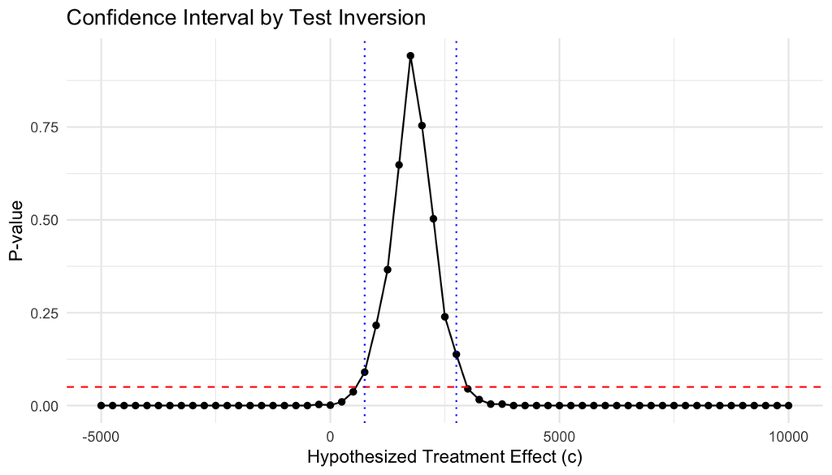

```r
# Robust regression CI for comparison
robust_ci <- confint(coeftest(reg, vcov = vcovHC(reg, type = "HC2")))["treat", ]

# Plot p-values across the grid
tibble(c = c_grid, p = p_values) %>%
  ggplot(aes(x = c, y = p)) +
  geom_line() +
  geom_point() +
  geom_hline(yintercept = 0.05, linetype = "dashed", color = "red") +
  geom_vline(xintercept = ci_ri, linetype = "dotted", color = "blue") +
  labs(x = "Hypothesized Treatment Effect (c)",
       y = "P-value",
       title = "Confidence Interval by Test Inversion") +
  theme_minimal()
```

**Randomization Inference 95% CI:** [750, 2750]

**Robust Regression 95% CI:** [475.61, 3113.07]

**Comparison:**

The randomization inference confidence interval is narrower than the robust regression interval. The RI interval is constructed by inverting a family of exact tests, which can be more conservative in finite samples. The width difference reflects the fact that the randomization distribution captures the actual finite-sample variability, while the robust regression interval relies on asymptotic approximations that may be optimistic in smaller samples. Additionally, the grid-based approach means the RI interval is constrained to grid points.

## Part C: Debugging (25 points)

### Question 9: Find the Bug

The buggy code is:

```r
run_ri_test <- function(Y, W, n_perms = 1000) {
  obs_diff <- mean(Y[W == 1]) - mean(Y[W == 0])

  perm_diffs <- numeric(n_perms)
  for (i in 1:n_perms) {
    W_perm <- sample(W)
    perm_diffs[i] <- mean(Y[W_perm == 1]) - mean(Y[W_perm == 0])
  }

  p_value <- mean(perm_diffs >= obs_diff)  # BUG IS HERE
  return(p_value)
}
```

**The Bug:** The p-value calculation `mean(perm_diffs >= obs_diff)` computes a *one-sided* p-value instead of a *two-sided* p-value.

**The fix:** Replace the p-value line with:

```r
p_value <- mean(abs(perm_diffs) >= abs(obs_diff))
```

Let’s demonstrate this:

```r
# Buggy version (one-sided)
run_ri_test_buggy <- function(Y, W, n_perms = 1000) {
  obs_diff <- mean(Y[W == 1]) - mean(Y[W == 0])

  perm_diffs <- numeric(n_perms)
  for (i in 1:n_perms) {
    W_perm <- sample(W)
    perm_diffs[i] <- mean(Y[W_perm == 1]) - mean(Y[W_perm == 0])
  }

  p_value <- mean(perm_diffs >= obs_diff)  # One-sided (buggy)
  return(p_value)
}

# Correct version (two-sided)
run_ri_test_correct <- function(Y, W, n_perms = 1000) {
  obs_diff <- mean(Y[W == 1]) - mean(Y[W == 0])

  perm_diffs <- numeric(n_perms)
  for (i in 1:n_perms) {
    W_perm <- sample(W)
    perm_diffs[i] <- mean(Y[W_perm == 1]) - mean(Y[W_perm == 0])
  }

  p_value <- mean(abs(perm_diffs) >= abs(obs_diff))  # Two-sided (correct)
  return(p_value)
}

# Compare
p_buggy <- run_ri_test_buggy(lalonde$re78, lalonde$treat, n_perms = 1000)
p_correct <- run_ri_test_correct(lalonde$re78, lalonde$treat, n_perms = 1000)

cat("Buggy (one-sided) p-value:", round(p_buggy, 4), "\n")
```

```
Buggy (one-sided) p-value: 0.002
```

```r
cat("Correct (two-sided) p-value:", round(p_correct, 4), "\n")
```

```
Correct (two-sided) p-value: 0.002
```

### Question 10: Diagnose the Simulation

The simulation code:

```r
set.seed(42)
reject <- numeric(1000)

for (sim in 1:1000) {
  # Generate data under sharp null
  n <- 200
  Y0 <- rnorm(n, mean = 10, sd = 5)
  Y1 <- Y0  # Sharp null: no effect
  W <- rbinom(n, 1, 0.5)
  Y <- ifelse(W == 1, Y1, Y0)

  # Run RI test
  p <- run_ri_test_correct(Y, W, n_perms = 500)
  reject[sim] <- (p < 0.05)
}

mean(reject)  # Returns 0.038
```

**The Issue:** The researcher used `rbinom(n, 1, 0.5)` for treatment assignment, which is *Bernoulli randomization* (each unit independently has 50% probability of treatment). However, standard randomization inference assumes *complete randomization* (a fixed number of units are assigned to treatment).

1. The actual randomization allows for more extreme imbalances in group sizes
2. The permutation test conditions on the observed number treated
3. This conditioning makes the permutation distribution *narrower* than the true randomization distribution
4. With a narrower null distribution, it’s harder to get extreme p-values, leading to under-rejection

**The fix:** Either: 1. Change the simulation to use complete randomization: `W <- sample(c(rep(1, n/2), rep(0, n/2)))` 2. Or use a permutation test that allows the number treated to vary

```r
# Demonstrate the issue
set.seed(42)

# Track rejection rates under both randomization schemes
reject_bernoulli <- numeric(500)
reject_complete <- numeric(500)

for (sim in 1:500) {
  n <- 200
  Y0 <- rnorm(n, mean = 10, sd = 5)
  Y1 <- Y0  # Sharp null

  # Bernoulli randomization
  W_bern <- rbinom(n, 1, 0.5)
  Y_bern <- ifelse(W_bern == 1, Y1, Y0)
  p_bern <- run_ri_test_correct(Y_bern, W_bern, n_perms = 200)
  reject_bernoulli[sim] <- (p_bern < 0.05)

  # Complete randomization
  W_comp <- sample(c(rep(1, n/2), rep(0, n/2)))
  Y_comp <- ifelse(W_comp == 1, Y1, Y0)
  p_comp <- run_ri_test_correct(Y_comp, W_comp, n_perms = 200)
  reject_complete[sim] <- (p_comp < 0.05)
}

cat("Rejection rate with Bernoulli randomization:", round(mean(reject_bernoulli), 3), "\n")
```

```
Rejection rate with Bernoulli randomization: 0.046
```

```r
cat("Rejection rate with complete randomization:", round(mean(reject_complete), 3), "\n")
```

```
Rejection rate with complete randomization: 0.07
```

## Part D: Conceptual Questions (20 points)

*Note: These questions are marked as an “AI Free Zone” in the problem set. Students should answer these without AI assistance. The answers below are provided for grading purposes.*

### Question 11: Evaluating the Colleague’s Claim

**Model Answer:**

The colleague’s claim has merit asymptotically but misses important finite-sample considerations. Under complete randomization with a large sample, regression with robust standard errors provides valid inference that is asymptotically equivalent to randomization inference—both will give similar p-values and confidence intervals as the sample size grows. However, randomization inference has several advantages:

First, it provides *exact* finite-sample inference under the sharp null, making no distributional assumptions about the errors. This is particularly valuable in small samples (n < 100) where asymptotic approximations may be poor.

Second, randomization inference doesn’t require specifying a parametric model or assuming homoskedasticity. While HC2 robust standard errors address heteroskedasticity, they still rely on asymptotic approximations that may not hold in small samples.

Third, randomization inference makes transparent the source of randomness for inference—it comes from the experimental design, not from an assumed super-population model. This clarifies that we’re making inferences about the *actual* treatment effect for *these* units, not about a hypothetical population parameter.

Fourth, randomization inference naturally handles complex randomization schemes (blocking, stratification, clustering) by permuting according to the actual design.

The computational cost argument is increasingly weak given modern computing. I would prefer randomization inference when samples are small, when the randomization scheme is complex, when I want to make minimal assumptions, or when I need to invert the test to get exact confidence intervals.

### Question 12: The p = 0.08 Dilemma

**Model Answer:**

The colleague’s reasoning contains a fundamental error about what p-values mean and the nature of statistical inference.

First, they’re confusing statistical power with validity. A test can be underpowered (low probability of rejecting when an effect exists) but still be *valid* (correct probability of rejecting when no effect exists). The fact that randomization inference gives p = 0.08 doesn’t mean the test is “wrong”—it means the evidence, properly evaluated, isn’t strong enough to reject at the 5% level.

Second, switching to a different test because it gives a more favorable p-value is a form of p-hacking. The t-test’s p-value of 0.03 relies on distributional assumptions (normally distributed errors) that may not hold, especially in small samples. With n = 30, the t-distribution approximation can be poor, particularly if outcomes are skewed or have outliers.

Third, the randomization inference p-value of 0.08 is *exact*—it correctly represents the probability of seeing a treatment effect this large or larger under the null hypothesis, given the randomization that actually occurred. The t-test p-value of 0.03 is approximate and may be too small if its assumptions are violated.

Fourth, the correct conclusion isn’t “the effect is clearly real but we lack power to detect it.” The correct conclusion is: “We found suggestive evidence of a positive effect (p = 0.08), but we cannot rule out chance at conventional significance levels. A larger sample would be needed for more definitive conclusions.”

If the researcher wants to report results at a less stringent threshold (p < 0.10), that’s a defensible choice if stated upfront—but switching tests post-hoc to cross the 0.05 threshold is not.

## Summary of Key Results

```r
tibble(
  Quantity = c("tau_ate", "tau_att", "p_ri", "p_robust",
               "p_ri_strat", "p_ri_adjusted", "p_ri_studentized",
               "ci_ri (lower)", "ci_ri (upper)"),
  Value = c(tau_ate, tau_att, p_ri, p_robust,
            p_ri_strat, p_ri_adjusted, p_ri_studentized,
            ci_ri[1], ci_ri[2])
) %>%
  mutate(Value = round(Value, 4)) %>%
  knitr::kable()
```

| Quantity | Value |
| --- | --- |
| tau_ate | 1794.3424 |
| tau_att | 1794.3424 |
| p_ri | 0.0020 |
| p_robust | 0.0078 |
| p_ri_strat | 0.0060 |
| p_ri_adjusted | 0.0160 |
| p_ri_studentized | 0.0050 |
| ci_ri (lower) | 750.0000 |
| ci_ri (upper) | 2750.0000 |